# UbiernaSanMamesMario_PEC3

[figure not shown]

M2.875 · Deep Learning · PEC3

2021-2 · Máster universitario en Ciencia de datos (Data science)

Estudios de Informática, Multimedia y Telecomunicación

# PEC 3: Recurrent Neural Networks

En esta práctica implementaremos redes neuronales recurrentes para generar música.

**Importante: La entrega debe hacerse en formato notebook y en formato html donde se vea el código y los resultados y comentarios de cada ejercicio. Para exportar el notebook a html puede hacerse desde el menú File $\to$ Download as $\to$ HTML.**

# Autor: Mario Ubierna San Mamés

# 0. Contexto y referencias

Esta PEC está basada en el siguiente [artículo de investigación](https://arxiv.org/pdf/1711.07682.pdf), aunque por motivos de extensión no podremos pasar por todos los puntos del artículo.

La primera etapa de esta PEC será leer y entender la idea general de este trabajo. El artículo os da acceso al código original con el que se ha llevado a cabo el trabajo y en el que además esta basado gran parte del código que aquí os adjuntamos, aunque por la complejidad y extensión del código no os recomendamos que sumergáis demasiado en él.

La PEC consta de una etapa de *interpretación de los datos* (un paso vital en todo proyecto real), donde se pedirá reproducir una gráfica del artículo. Luego *entrenaremos* una red LSTM para generar acordes a partir de archivos MIDI. Finalmente, usaremos la capa de *embedding* de la red entrenada para hacer una proyección de los acordes en 2D y visualizar el concepto de [word2vec](https://en.wikipedia.org/wiki/Word2vec).

Además de este fichero os hemos adjuntado un archivo comprimido con una estructura de datos similar a la usada en el artículo y que os recomendamos (por vuestro bien) que no modifiquéis :). Allí encontraréis una carpeta llamada *data* donde se encuentra la base de datos que usaremos y otros ficheros que os facilitamos con datos de redes ya entrenadas (en la carpeta *models*)

# 1. Procesado de datos [2.5 pts]

## 1.1 Importación de módulos y paquetes necesarios

```python
!pip install pretty_midi==0.2.8
```

```
     |████████████████████████████████| 5.6 MB 5.3 MB/s
     |████████████████████████████████| 51 kB 2.5 MB/s
```

```python
from google.colab import drive
drive.mount('/content/drive')
```

```python
# añade el path a tu directorio
#%cd /content/drive/MyDrive/UOC PACs/PAC3/
%cd /content/drive/MyDrive/PEC3_PAC3
```

```
/content/drive/MyDrive/PEC3_PAC3
```

```python
import numpy as np
import matplotlib.pyplot as plt
import _pickle as pickle
import os
import sys
import pretty_midi as pm
import mido
from collections import Counter
import collections
import pandas as pd
```

importamos módulos propios (archivos .py) que podréis encontrar en la estructura de carpetas que os hemos facilitado

```python
from settings import *
import midi_functions as mf
import data_processing_functions as dpf
```

## 1.2 Ficheros MIDI [1 pt]

En esta sección vamos a entender un poco mejor la información que contiene un fichero MIDI y reproduciremos un archivo de nuestra base de datos. Para esta sección os recomendamos que le echéis un vistazo a la sección "*Extract notes*" del siguiente [tutorial de tensorflow](https://www.tensorflow.org/tutorials/audio/music_generation).

1.2.1 Escoger un fichero MIDI de la base de datos y crear las funciones necesarias para extraer las notas, el tiempo en que se toca cada nota, su duración y el momento en que se tocan. Este proceso se debe aplicar solo a un instrumento: **"Acoustic Grand Piano"**.

*nota: Si el fichero escogido no tiene piano elegir otro fichero*

```python
# Comprobamos si hay un archivo que tanga un solo instrumento y que éste sea Acoustic Grand Piano
data_directory = "/content/drive/MyDrive/PEC3_PAC3/data/original/"

for filename in os.listdir(data_directory):

  midifile = pm.PrettyMIDI(os.path.join(data_directory, filename))
  instruments = [pm.program_to_instrument_name(instrument.program) for instrument in midifile.instruments]

  if "Acoustic Grand Piano" in instruments and len(instruments) == 1:
    print("**************************************************************")
    print(filename)
    print("\n\tNúmero de instrumentos: " + str(len(midifile.instruments)))
    print("\tNúmero de instrumentos: " + str(instruments))
    print("**************************************************************\n\n")
    break
```

```
1ae49af2dc6cdb068d749b464f330441.mid

	Número de instrumentos: 1
	Número de instrumentos: ['Acoustic Grand Piano']
```

```python
# https://www.tensorflow.org/tutorials/audio/music_generation#extract_notes
# función obtenida del apartado "Extract notes"
def midi_to_notes(midifile):
  midi = pm.PrettyMIDI(midifile)
  instrument = midi.instruments[0]
  notes = collections.defaultdict(list)

  # Sort the notes by start time
  sorted_notes = sorted(instrument.notes, key=lambda note: note.start)
  prev_start = sorted_notes[0].start

  for note in sorted_notes:
    start = note.start
    end = note.end
    notes['pitch'].append(note.pitch)
    notes['note'].append(pm.note_number_to_name(note.pitch))
    notes['start'].append(start)
    notes['end'].append(end)
    notes['duration'].append(end - start)
    notes['step'].append(start - prev_start)
    prev_start = start

  return pd.DataFrame({name: np.array(value) for name, value in notes.items()})
```

```python
df_piano = midi_to_notes(os.path.join(data_directory, "1ae49af2dc6cdb068d749b464f330441.mid"))
df_piano.head()
```

|  | pitch | note | start | end | duration | step |
| --- | --- | --- | --- | --- | --- | --- |
| 0 | 59 | B3 | 1.750000 | 3.076969 | 1.326969 | 0.000000 |
| 1 | 56 | G#3 | 2.807739 | 3.211585 | 0.403846 | 1.057739 |
| 2 | 64 | E4 | 2.807739 | 3.942354 | 1.134615 | 0.000000 |
| 3 | 40 | E2 | 2.807739 | 5.026399 | 2.218661 | 0.000000 |
| 4 | 59 | B3 | 3.384662 | 3.798123 | 0.413461 | 0.576923 |

1.2.2 Modificar la funcion *plot_piano_roll* del tutorial para poder graficar el pianoroll de la canción MIDI escogida. En este caso deberemos poder indicar un tiempo máximo de la canción que queremos añadir en el pianoroll. Además, si pasamos un *max_time=-1*, se deberán graficar todas las notas de la canción

```python
# https://www.tensorflow.org/tutorials/audio/music_generation#extract_notes
def plot_piano_roll(notes, max_time=-1):
  if max_time == -1:
    title = f'Canción entera'
    max_time = len(notes['pitch'])
  else:
    if max_time <= 0:
       title = f'Canción hasta el segundo 0'
       max_time = 0
    title = f'Canción hasta el segundo {max_time}'
    max_time = len(df_piano[df_piano["end"] <= max_time])

  plt.figure(figsize=(20, 4))
  plot_pitch = np.stack([notes['pitch'], notes['pitch']], axis=0)
  plot_start_stop = np.stack([notes['start'], notes['end']], axis=0)
  plt.plot(
      plot_start_stop[:, :max_time], plot_pitch[:, :max_time], color="b", marker=".")
  plt.xlabel('Tiempo [s]')
  plt.ylabel('Pitch (nota midi)')
  _ = plt.title(title)
```

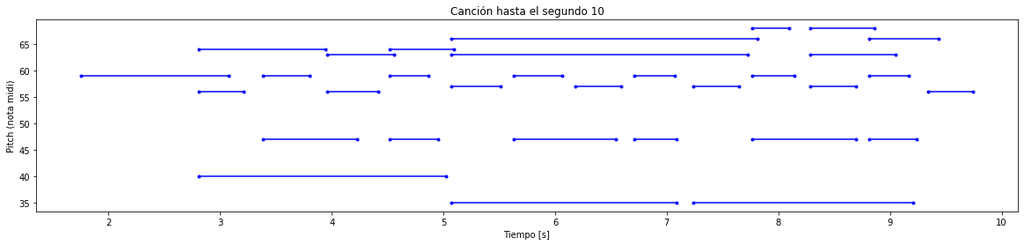

```python
plot_piano_roll(df_piano, max_time=10)
```

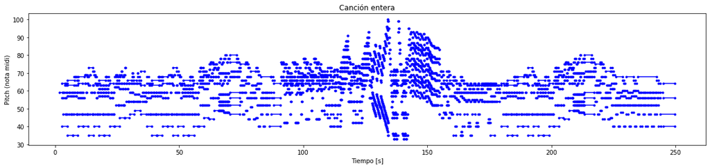

```python
plot_piano_roll(df_piano, max_time=-1)
```

## 1.3 Procesado de datos [1.5 pts]

Ahora volvemos al artículo y aplicaremos el procesado de datos. Buscar dentro del fichero *data_processing_functions.py* la función que se encarga de llevar a cabo todo el procesado de datos y llamarla desde aquí

```python
dpf.do_all_steps()
```

```
changing Tempo
histogramming
data/tempo/
```

```
make song histo
shifting midi files
making note indexes
histogramming
data/shifted/tempo/
extracting chords
getting dictionary
converting chords to index sequences
done
```

1.3.1 ¿Qué hace la función *change_tempo_folder*?¿Qué bpm fija para las canciones?

La función lo que hace es cambiar el tempo de los archivos midi originales, es decir, va recorriendo la carpeta `data/original` y cada archivo que encuentra genera un nuevo archivo y modifica el tempo correspondiente en la carpeta `data/tempo`.

El tempo que establece para cada canción es de `500000`. Realmente dicho valor no sé que significa, porque segundos no son, sin embargo, cuando ejecutamos el método `change_tempo_folder` lo que hace es reducir el tiempo de la canción, por lo que ese `new_msg.tempo = 500000` aumenta el tempo de cada pista que hay en el archivo midi.

1.3.2 Una vez tenemos ejecutado el procesado de datos se habrán creado muchas carpetas y muchos ficheros nuevos en la actual carpeta *data*. Ahora usaremos algunos de estos ficheros para construir la figura 2 del artículo usando los datos procesados. Crearemos dos funciones:

- my_save_histo_oct_from_midi_folder
- my_midi_to_histo_oct

basadas en las funciones *save_histo_oct_from_midi_folder* y *midi_to_histo_oct* que encontraréis en los ficheros *midi_functions.py* y *data_processing_functions.py*. Ahora las modificaremos para que nos devuelvan datos para dos tipos de histogramas: uno igual a la figura 2 del artículo (apariciones VS pitch) y otro, usando el *histo_oct*, que serán datos para graficar *apariciones VS notas en cualquier octava*, es decir, el número de veces que aparece una nota (sin importar a que octava pertenezca) a lo largo de una canción.

*indicación: Es importante entender la estructura de las variables:*

- pianoroll
- histo_bar
- histo_oct

*dentro de la funcion* *midi_to_histo_oct*

```python
#usa este vector como labels del segundo gráfico
notas_en_una_octava = ['C','C#','D','D#','E','F','F#','G','G#','A','A#','B']
```

```python
def my_save_histo_oct_from_midi_folder(tempo_folder, histo_folder):
  lst_histo_bar = np.zeros(shape=128) # 128 es fijo por el número de pitches
  lst_histo_oct = np.zeros(shape=12) # 12 es fijo por el número de notas en una escala

  print(tempo_folder)
  nfiles=0
  for path, subdirs, files in os.walk(tempo_folder):
      for name in files:
          _path = path.replace('\\', '/') + '/'
          _name = name.replace('\\', '/')
          target_path = histo_folder+_path[len(tempo_folder):]
          if not os.path.exists(target_path):
              os.makedirs(target_path)
          try:
              nfiles+=1
              if nfiles%100==0:
                print("File #",nfiles,"Current file = ",_path,"/",_name)

              # Recuperando los histogramas para cada canción
              histo_bar, histo_oct = my_midi_to_histo_oct(samples_per_bar,octave, fs, _name, _path, target_path)

              # Haciendo el sumatorio para cada canción y así cuando termine obtener el histograma final
              lst_histo_bar += np.sum(histo_bar, axis=1)
              lst_histo_oct += np.sum(histo_oct, axis=1)

          except (ValueError, EOFError, IndexError, OSError, KeyError, ZeroDivisionError) as e:
              exception_str = 'Unexpected error in ' + name  + ':\n', e, sys.exc_info()[0]
              print(exception_str)

  return lst_histo_bar, lst_histo_oct

def my_midi_to_histo_oct(samples_per_bar, octave, fs, name, path, histo_path):
  pianoroll = mf.get_pianoroll(name, path, fs)
  histo_bar = mf.pianoroll_to_histo_bar(pianoroll, samples_per_bar)
  histo_oct = mf.histo_bar_to_histo_oct(histo_bar, octave)

  return histo_bar, histo_oct
```

```python
histo_bar, histo_oct = my_save_histo_oct_from_midi_folder(
    tempo_folder=tempo_folder1,
    histo_folder=histo_folder1
)
```

```
data/tempo/
```

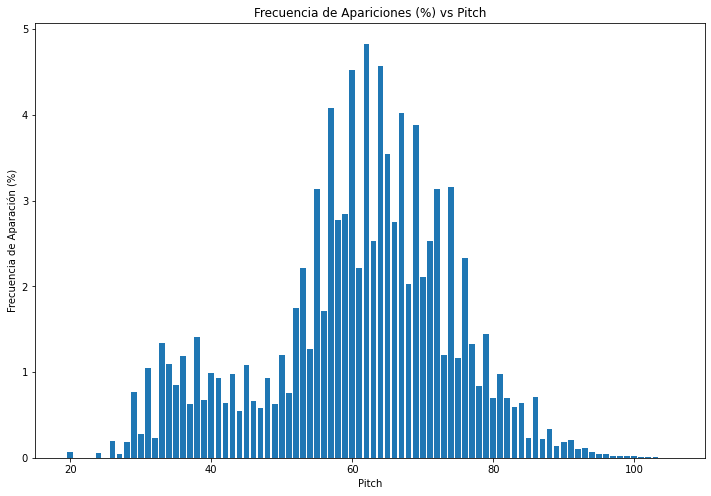

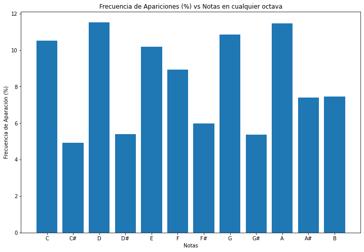

```python
# Generamos los histogramas

# Histograma Aparaciones vs Pitch
histo_bar_fr = (histo_bar / np.sum(histo_bar)) * 100
fig, ax = plt.subplots(figsize=(12,8))
plt.bar(range(0,128), histo_bar_fr)
plt.xlim(15,110)
plt.title("Frecuencia de Apariciones (%) vs Pitch")
plt.xlabel("Pitch")
plt.ylabel("Frecuencia de Aparación (%)")
plt.show()

# Histograma Aparaciones vs Notas en cualquier octava
histo_oct_fr = (histo_oct / np.sum(histo_oct)) * 100
fig, ax = plt.subplots(figsize=(12,8))
plt.bar(notas_en_una_octava, histo_oct_fr)
plt.title("Frecuencia de Apariciones (%) vs Notas en cualquier octava")
plt.xlabel("Notas")
plt.ylabel("Frecuencia de Aparación (%)")
plt.show()
```

1.3.3 Buscar en internet sobre las escalas musicales e indicar que escala es la que más aparece en todas las canciones analizadas. ¿Cuáles dirías que son las notas más importantes de la escala?

La escala mayoritariamente representada en las canciones, es la escala de Do Mayor, es decir, aquella formada por las notas:

- Do - Re - Mi - Fa - Sol - La - Si.
- C - D - E - F - G - A - B.

Llegamos a esta conclusión gracias al gráfico "Frecuncia de Aparaciones (%) vs Notas en cualquier octava", si analizamos dicho gráfico vemos que las notas mencionadas anteriormente son las más utilizadas.

Las notas más importantes de esta escala son:

- Re (D), La (A), Sol (G), Do (C).

Y las menos importantes:

- Mi (E), Fa (F), Si (B).

# 2. LSTM para acordes [5 pts]

El siguiente paso en el artículo es el entrenamiento de una red LSTM para la generación de acordes. Esta parte la haremos con un data set más pequeño y lo compararemos con resultados de entrenamientos previos que os faciliaremos. Primero cargamos la librerias que necesitaremos

```python
from keras.models import Sequential
from keras.layers import LSTM
from keras.layers import Dense, Activation
from keras.layers import Embedding
from tensorflow.keras.optimizers import RMSprop, Adam
import tensorflow as tf
from tensorflow.compat.v1.keras.backend import set_session
import keras.utils
from keras.utils import np_utils
from random import shuffle
import progressbar
import time
```

## 2.1 Carga de datos [0.5 pts]

2.1.1 En la carpeta *data* encontraréis un fichero llamado *dataset.pkl* que contiene 11338 canciones de train y 3780 de test. Usando *pickle* cargar los datos y luego separar 2000 para *train* y 500 canciones para *test* en las variables:

- train_set
- test_set

crea además *train_set_size* y *test_set_size*

```python
# Definimos los tamaños de los conjuntos de train y test
train_set_size = 2000
test_set_size = 500

# Cargamos los datos
dataset = pickle.load(open("data/dataset.pkl", "rb"))

# Dividimos el dataset en train y test
train_set = dataset[0]
test_set = dataset[1]

# Reducimos el tamaño de los conjuntos
train_set = train_set[:train_set_size]
test_set = test_set[:test_set_size]

# Comprobamos el tamaño de los conjuntos
print("El tamaño de train es: " + str(len(train_set)))
print("El tamaño de test es: " + str(len(test_set)))
```

```
El tamaño de train es: 2000
El tamaño de test es: 500
```

## 2.2 Modelo con una capa de *Embedding* [0.5 pts]

2.2.1 Ahora definiremos los parámetros de nuestra red LSTM usando los parámetros que dan en el artículo. El único cambio será en el tamaño de la red LSTM, en la que usaremos la mitad de la LSTM del artículo y número de epochs que usaremos 10 en nuestro caso

```python
batch_size = 1
step_size = 1
epochs = 10

#completar
lstm_size = int(256 / 2) # Chord LSTM = 256 y Polyphonic LSTM = 512
learning_rate = 0.00001 # Chord LSTM = 10^-5 y Polyphonic LSTM = 10^-6
optimizer = "Adam" # En ambas redes
```

El siguiente código es para mantener la estructura de carpetas que usan en el artículo ya que hay mucho código que depende de esta estructura:

```python
##--------NO TOCAR-------------------------------------------------------
base_path = 'models/chords/'
model_filetype = '.pickle'

shuffle_train_set = True
bidirectional = False

#Create model dir
fd = {'shifted': shifted, 'lr': learning_rate, 'emdim': chord_embedding_dim, 'opt': optimizer,
'bi': bidirectional, 'lstms': lstm_size, 'trainsize': train_set_size, 'testsize': test_set_size, 'samples_per_bar': samples_per_bar}
t = str(np.random.randint(1000,9999))
model_name = t+ '-Shifted_%(shifted)s_Lr_%(lr)s_EmDim_%(emdim)s_opt_%(opt)s_bi_%(bi)s_lstmsize_%(lstms)s_trainsize_%(trainsize)s_testsize_%(testsize)s_samples_per_bar%(samples_per_bar)s' % fd
model_path = base_path + model_name + '/'
if not os.path.exists(model_path):
    os.makedirs(model_path)
##--------NO TOCAR-------------------------------------------------------
```

```python
print(model_name)
print(model_path)
```

```
8945-Shifted_True_Lr_1e-05_EmDim_10_opt_Adam_bi_False_lstmsize_128_trainsize_2000_testsize_500_samples_per_bar8
models/chords/8945-Shifted_True_Lr_1e-05_EmDim_10_opt_Adam_bi_False_lstmsize_128_trainsize_2000_testsize_500_samples_per_bar8/
```

2.2.2 Finalmente definimos y compilamos la red con una capa de Embedding antes de la LSTM. Para este paso, acceder al código original del artículo y buscar en que fichero se entrena la LSTM copiar la estructura eliminando código que no es de nuestro interés

```python
# Definimos la red
model = Sequential()
model.add(Embedding(num_chords, chord_embedding_dim, input_length=step_size, name="embedding", batch_input_shape=(batch_size,step_size)))
model.add(LSTM(lstm_size, stateful=True))
model.add(Dense(num_chords))
model.add(Activation('softmax'))

optimizer = Adam(learning_rate=learning_rate)
loss = 'categorical_crossentropy'

# Compilamos la red
model.compile(optimizer, loss)
```

## 2.3 Entrenamiento [2 pts]

2.3.1 Siguiendo el código orginal del artículo donde se define la arquitectura de la LSTM para los acordes hay 3 funciones más:

- test()
- train()
- save_params()

que nos serán de ayuda para el entrenamiento, testeo y para guardar los datos sobre el modelo entrenado. Guardaremos el valor de la *loss* tanto para test como para train cada 500 canciones, por lo que tendremos más de un punto por epoch. Modifica, si es necesario, las funciones *test()* y *train()* para que los ficheros de *total_test* y *total_train* dejen constancia de la epoch a la que pertenecen, esto te ayudará al graficar los datos más adelante.

Añade, antes de cada función una cabecera explicando brevemente lo que ésta hace.

*nota: comprueba que has definido todas las variables necesarias para que las* *funciones no den error en mitad del entrenamiento. Comienza usando menos datos* *para agilizar el proceso y una vez funcione todo usa el set completo*

```python
for i, song in enumerate(train_set[:1]):
  print("*"*100)
  print("Song:")
  print(song)
  print("X:")
  print(song[:-1])
  print("Y:")
  print(song[1:])
  print(np_utils.to_categorical(song[1:], num_classes=num_chords))
  print("*"*100)
```

```
Song:
[1, 10, 5, 0, 6, 1, 4, 15, 12, 12, 1, 10, 5, 0, 6, 1, 10, 15, 12, 26, 0, 0, 0, 0, 0, 0, 2, 1, 10, 5, 0, 6, 1, 10, 15, 12, 12, 26]
X:
[1, 10, 5, 0, 6, 1, 4, 15, 12, 12, 1, 10, 5, 0, 6, 1, 10, 15, 12, 26, 0, 0, 0, 0, 0, 0, 2, 1, 10, 5, 0, 6, 1, 10, 15, 12, 12]
Y:
[10, 5, 0, 6, 1, 4, 15, 12, 12, 1, 10, 5, 0, 6, 1, 10, 15, 12, 26, 0, 0, 0, 0, 0, 0, 2, 1, 10, 5, 0, 6, 1, 10, 15, 12, 12, 26]
[[0. 0. 0. ... 0. 0. 0.]
 [0. 0. 0. ... 0. 0. 0.]
 [1. 0. 0. ... 0. 0. 0.]
 ...
 [0. 0. 0. ... 0. 0. 0.]
 [0. 0. 0. ... 0. 0. 0.]
 [0. 0. 0. ... 0. 0. 0.]]
```

```python
epoch_array=[]
total_test_loss_array = []
total_train_loss_array = []
total_test_loss = 0
show_plot = False
save_plot = False
test_step = 500
verbose = False
save_step = 1


#crea aquí las funciones test(), train() y save_params()

# La función test se encarga de probar el conjunto de test cada X tiempo,
# es decir, evalúa la pérdida que hay en el conjunto cada vez que lo indique
# la variable test_step, en nuestro caso ésta es 500, por lo que cada 500
# canciones se va a evaluar el modelo.
def test():
  print('\nTesting:')
  total_test_loss = 0

  bar = progressbar.ProgressBar(maxval=test_set_size, redirect_stdout=False)
  for i, test_song in enumerate(test_set):
      X_test = np.array(test_song[:-1])
      Y_test = np.array(np_utils.to_categorical(test_song[1:], num_classes=num_chords))
      loss = model.evaluate(X_test, Y_test, batch_size=batch_size, verbose=verbose)
      model.reset_states()
      bar.update(i+1)

      total_test_loss += loss

  total_test_loss_array.append(total_test_loss/test_set_size)
  print('\nTotal test loss: ', total_test_loss/test_set_size)
  print('-'*50)

  # plt.plot(total_test_loss_array, 'b-', label='test loss')
  # plt.plot(total_train_loss_array, 'r-', label='train loss')
  # plt.ylabel(model_path)
  # plt.grid()

  if show_plot: plt.show()
  if save_plot: plt.savefig(model_path+'plot.png')
  pickle.dump([epoch_array, total_test_loss_array],open(model_path +'total_test_loss_array.pickle', 'wb'))
  pickle.dump([epoch_array, total_train_loss_array],open(model_path +'total_train_loss_array.pickle', 'wb'))

# La función train se encarga del entrenamiento del modelo, para ello va a realizar el
# entrenamiento tantas veces como épocas le indiquemos, en nuestro caso 10. Para cada época
# va a ir calculando la pérdida y cuando llega a 500 (variable test_step) se realiza el
# guardado tanto de la pérdida de train como de test.
def train():
  print('training model...')
  total_train_loss = 0
  epoch_array_real_time = [i/4 for i in range(1, int(epochs * (train_set_size/test_step)) + 1)]
  index_epoch_array_real_time = 0

  for e in range(1, epochs+1):
      print('Epoch ', e, 'of ', epochs, 'Epochs\nTraining:')
      if shuffle_train_set:
          shuffle(train_set)
      bar = progressbar.ProgressBar(maxval=train_set_size)
      for i, song in enumerate(train_set):
        # bar.start()
        X = np.array(song[:-1])
        Y = np.array(np_utils.to_categorical(song[1:], num_classes=num_chords))
        hist = model.fit(X, Y, batch_size=batch_size, shuffle=False, verbose=verbose)
        model.reset_states()
        bar.update(i+1)
#            print(hist.history)

        total_train_loss += hist.history['loss'][0]
        if (i+1)%test_step is 0:
            total_train_loss = total_train_loss/test_step
            total_train_loss_array.append(total_train_loss)
            epoch_array.append(epoch_array_real_time[index_epoch_array_real_time])
            test()
            total_train_loss = 0
            index_epoch_array_real_time +=1

      if e%save_step is 0:
          print('saving model')
          model_save_path = model_path + 'model_' + 'Epoch' + str(e) + '_' + str(i+1) + model_filetype
          model.save(model_save_path)

# Esta función se encarga de guardar en un fichero .txt los parámetros utilizados en el entranamiento.
# Dicho fichero se va a localizar en la carpeta generada para el modelo.
def save_params():
  with open(model_path + 'params.txt', "w") as text_file:
    text_file.write("epochs: %s" % epochs + '\n')
    text_file.write("train_set_size: %s" % train_set_size + '\n')
    text_file.write("test_set_size: %s" % test_set_size + '\n')
    text_file.write("lstm_size: %s" % lstm_size + '\n')
    text_file.write("embedding_dim: %s" % chord_embedding_dim + '\n')
    text_file.write("learning_rate: %s" % learning_rate + '\n')
    #text_file.write("save_step: %s" % save_step + '\n')
    text_file.write("shuffle_train_set: %s" % shuffle_train_set + '\n')
    text_file.write("test_step: %s" % test_step + '\n')
    text_file.write("bidirectional: %s" % bidirectional + '\n')
    text_file.write("num_chords: %s" % num_chords + '\n')
    text_file.write("chord_n: %s" % chord_n + '\n')
```

2.3.2 Responde las siguientes preguntas:

- ¿Qué representa cada elemento de *X* en la función de *train()*?

Cada elemento X de la función train está representando una canción, la cual está formada por un conjunto de acordes, donde cada elemento del array indica el acorde correspondiente de la canción.

Para ello se introduce todos los acordes de la canción menos el último.

- ¿Qué se está usando como *label* para cada elemento de *X*?

Como label se está usando todos los acordes que hay en la canción, con excepción del primero, es decir, a la red neuronal se le pasa toda la canción menos el úlitmo acorde, y como label se usa toda la canción menos el primer acorde.

- Justifica el uso de *categorical_crossentropy* como función de loss

En este caso estamos en un problema de clasificación, pero no es clasificación binaria, es decir, la variable objetivo no es 0 o 1 (por ejemplo si existe un acorde o no). Este problema lo que busca resolver es identificar un patrón en los datos para predecir cual sería el siguiente acorde, es decir, hay 50 acordes y todos ellos son excluyentes entre sí, por lo tanto estamos en un probleam de clasificación multiclase (hay varias clases, para se más exactos hay 50).

Al ser un problema de clasificación de multiclases se usa la categorical cross entropy, de lo contrario se usaría la binary cross entropy.

Un detalle por si hay dudas es ver qué función de activación se usa en la capa de salida, si es binaria se usa una sigmoide, pero al ser un problema de múltiples clases se usa softmax.

- ¿Qué crees que está aprendiendo la red?

La diferencia entre la entrada de la red y la salida es básicamente una, en la entrada se introducen todos los acordes menos el último, y para la salida se comparan todos los acordes menos el primero.

Con la anterior lo que quiero decir es que la red neuronal busca patrones en los datos de entrada para predecir una secuencia de acordes, es decir, a partir de unos acordes cuál sería el siguiente que se podría utilizar.

Esto es básicamente lo que aprende la red, el saber qué acordes de los 50 disponibles se puedan usar para continuar con la canción.

2.3.3 Entrena la red usando las funciones anteriores

```python
print("saving params")
save_params()
print("starting training..")
train()
```

```
saving params
starting training..
training model...
Epoch  1 of  10 Epochs
Training:
```

```
 25% (500 of 2000) |#####                | Elapsed Time: 0:03:05 ETA:   0:11:20
```

```
Testing:
```

```
100% (500 of 500) |######################| Elapsed Time: 0:01:53 ETA:  00:00:00
```

```
Total test loss:  3.1931820752620697
--------------------------------------------------
```

```
N/A% (0 of 500) |                        | Elapsed Time: 0:00:00 ETA:  --:--:--
```

```
Testing:
```

```
100% (500 of 500) |######################| Elapsed Time: 0:01:58 ETA:  00:00:00
```

```
Total test loss:  3.1710480122566223
--------------------------------------------------
```

```
N/A% (0 of 500) |                        | Elapsed Time: 0:00:00 ETA:  --:--:--
```

```
Testing:
```

```
100% (500 of 500) |######################| Elapsed Time: 0:01:56 ETA:  00:00:00
```

```
Total test loss:  3.114895385026932
--------------------------------------------------
```

```
N/A% (0 of 500) |                        | Elapsed Time: 0:00:00 ETA:  --:--:--
```

```
Testing:
```

```
100% (500 of 500) |######################| Elapsed Time: 0:01:50 ETA:  00:00:00
```

```
Total test loss:  3.1169390454292296
--------------------------------------------------
saving model
```

[output not shown]

```
INFO:tensorflow:Assets written to: models/chords/8945-Shifted_True_Lr_1e-05_EmDim_10_opt_Adam_bi_False_lstmsize_128_trainsize_2000_testsize_500_samples_per_bar8/model_Epoch1_2000.pickle/assets
```

[output not shown]

```
Epoch  2 of  10 Epochs
Training:
```

```
N/A% (0 of 500) |                        | Elapsed Time: 0:00:00 ETA:  --:--:--
```

```
Testing:
```

```
100% (500 of 500) |######################| Elapsed Time: 0:01:51 ETA:  00:00:00
```

```
Total test loss:  3.0705467684268952
--------------------------------------------------
```

```
N/A% (0 of 500) |                        | Elapsed Time: 0:00:00 ETA:  --:--:--
```

```
Testing:
```

```
100% (500 of 500) |######################| Elapsed Time: 0:01:51 ETA:  00:00:00
```

```
Total test loss:  3.0633127477169038
--------------------------------------------------
```

```
N/A% (0 of 500) |                        | Elapsed Time: 0:00:00 ETA:  --:--:--
```

```
Testing:
```

```
100% (500 of 500) |######################| Elapsed Time: 0:01:49 ETA:  00:00:00
```

```
Total test loss:  3.055948158740997
--------------------------------------------------
```

```
N/A% (0 of 500) |                        | Elapsed Time: 0:00:00 ETA:  --:--:--
```

```
Testing:
```

```
100% (500 of 500) |######################| Elapsed Time: 0:01:51 ETA:  00:00:00
```

```
Total test loss:  3.051659468173981
--------------------------------------------------
saving model
```

[output not shown]

```
INFO:tensorflow:Assets written to: models/chords/8945-Shifted_True_Lr_1e-05_EmDim_10_opt_Adam_bi_False_lstmsize_128_trainsize_2000_testsize_500_samples_per_bar8/model_Epoch2_2000.pickle/assets
```

[output not shown]

```
Epoch  3 of  10 Epochs
Training:
```

```
N/A% (0 of 500) |                        | Elapsed Time: 0:00:00 ETA:  --:--:--
```

```
Testing:
```

```
100% (500 of 500) |######################| Elapsed Time: 0:01:51 ETA:  00:00:00
```

```
Total test loss:  3.0304313535690306
--------------------------------------------------
```

```
N/A% (0 of 500) |                        | Elapsed Time: 0:00:00 ETA:  --:--:--
```

```
Testing:
```

```
100% (500 of 500) |######################| Elapsed Time: 0:01:56 ETA:  00:00:00
```

```
Total test loss:  3.030498951435089
--------------------------------------------------
```

```
N/A% (0 of 500) |                        | Elapsed Time: 0:00:00 ETA:  --:--:--
```

```
Testing:
```

```
100% (500 of 500) |######################| Elapsed Time: 0:01:54 ETA:  00:00:00
```

```
Total test loss:  3.019024733781815
--------------------------------------------------
```

```
N/A% (0 of 500) |                        | Elapsed Time: 0:00:00 ETA:  --:--:--
```

```
Testing:
```

```
100% (500 of 500) |######################| Elapsed Time: 0:01:56 ETA:  00:00:00
```

```
Total test loss:  3.0131524679660795
--------------------------------------------------
saving model
```

[output not shown]

```
INFO:tensorflow:Assets written to: models/chords/8945-Shifted_True_Lr_1e-05_EmDim_10_opt_Adam_bi_False_lstmsize_128_trainsize_2000_testsize_500_samples_per_bar8/model_Epoch3_2000.pickle/assets
```

[output not shown]

```
Epoch  4 of  10 Epochs
Training:
```

```
N/A% (0 of 500) |                        | Elapsed Time: 0:00:00 ETA:  --:--:--
```

```
Testing:
```

```
100% (500 of 500) |######################| Elapsed Time: 0:01:59 ETA:  00:00:00
```

```
Total test loss:  3.006427509307861
--------------------------------------------------
```

```
 50% (1000 of 2000) |##########          | Elapsed Time: 0:08:00 ETA:   0:05:33
```

```
Testing:
```

```
100% (500 of 500) |######################| Elapsed Time: 0:01:57 ETA:  00:00:00
```

```
Total test loss:  2.989778675317764
--------------------------------------------------
```

```
N/A% (0 of 500) |                        | Elapsed Time: 0:00:00 ETA:  --:--:--
```

```
Testing:
```

```
100% (500 of 500) |######################| Elapsed Time: 0:01:55 ETA:  00:00:00
```

```
Total test loss:  2.9934910864830018
--------------------------------------------------
```

```
N/A% (0 of 500) |                        | Elapsed Time: 0:00:00 ETA:  --:--:--
```

```
Testing:
```

```
100% (500 of 500) |######################| Elapsed Time: 0:01:54 ETA:  00:00:00
```

```
Total test loss:  2.9818686418533327
--------------------------------------------------
saving model
```

[output not shown]

```
INFO:tensorflow:Assets written to: models/chords/8945-Shifted_True_Lr_1e-05_EmDim_10_opt_Adam_bi_False_lstmsize_128_trainsize_2000_testsize_500_samples_per_bar8/model_Epoch4_2000.pickle/assets
```

[output not shown]

```
Epoch  5 of  10 Epochs
Training:
```

```
N/A% (0 of 500) |                        | Elapsed Time: 0:00:00 ETA:  --:--:--
```

```
Testing:
```

```
100% (500 of 500) |######################| Elapsed Time: 0:01:56 ETA:  00:00:00
```

```
Total test loss:  2.9677823214530945
--------------------------------------------------
```

```
N/A% (0 of 500) |                        | Elapsed Time: 0:00:00 ETA:  --:--:--
```

```
Testing:
```

```
100% (500 of 500) |######################| Elapsed Time: 0:01:55 ETA:  00:00:00
```

```
Total test loss:  2.9706240384578706
--------------------------------------------------
```

```
N/A% (0 of 500) |                        | Elapsed Time: 0:00:00 ETA:  --:--:--
```

```
Testing:
```

```
100% (500 of 500) |######################| Elapsed Time: 0:01:55 ETA:  00:00:00
```

```
Total test loss:  2.970767486333847
--------------------------------------------------
```

```
N/A% (0 of 500) |                        | Elapsed Time: 0:00:00 ETA:  --:--:--
```

```
Testing:
```

```
100% (500 of 500) |######################| Elapsed Time: 0:01:51 ETA:  00:00:00
```

```
Total test loss:  2.967471867799759
--------------------------------------------------
saving model
```

[output not shown]

```
INFO:tensorflow:Assets written to: models/chords/8945-Shifted_True_Lr_1e-05_EmDim_10_opt_Adam_bi_False_lstmsize_128_trainsize_2000_testsize_500_samples_per_bar8/model_Epoch5_2000.pickle/assets
```

[output not shown]

```
Epoch  6 of  10 Epochs
Training:
```

```
N/A% (0 of 500) |                        | Elapsed Time: 0:00:00 ETA:  --:--:--
```

```
Testing:
```

```
100% (500 of 500) |######################| Elapsed Time: 0:01:54 ETA:  00:00:00
```

```
Total test loss:  2.9597561777830124
--------------------------------------------------
```

```
N/A% (0 of 500) |                        | Elapsed Time: 0:00:00 ETA:  --:--:--
```

```
Testing:
```

```
100% (500 of 500) |######################| Elapsed Time: 0:01:55 ETA:  00:00:00
```

```
Total test loss:  2.961755524516106
--------------------------------------------------
```

```
N/A% (0 of 500) |                        | Elapsed Time: 0:00:00 ETA:  --:--:--
```

```
Testing:
```

```
100% (500 of 500) |######################| Elapsed Time: 0:01:53 ETA:  00:00:00
```

```
Total test loss:  2.95194156229496
--------------------------------------------------
```

```
N/A% (0 of 500) |                        | Elapsed Time: 0:00:00 ETA:  --:--:--
```

```
Testing:
```

```
100% (500 of 500) |######################| Elapsed Time: 0:01:56 ETA:  00:00:00
```

```
Total test loss:  2.948941522717476
--------------------------------------------------
saving model
```

[output not shown]

```
INFO:tensorflow:Assets written to: models/chords/8945-Shifted_True_Lr_1e-05_EmDim_10_opt_Adam_bi_False_lstmsize_128_trainsize_2000_testsize_500_samples_per_bar8/model_Epoch6_2000.pickle/assets
```

[output not shown]

```
Epoch  7 of  10 Epochs
Training:
```

```
N/A% (0 of 500) |                        | Elapsed Time: 0:00:00 ETA:  --:--:--
```

```
Testing:
```

```
100% (500 of 500) |######################| Elapsed Time: 0:01:54 ETA:  00:00:00
```

```
Total test loss:  2.9451075760126115
--------------------------------------------------
```

```
N/A% (0 of 500) |                        | Elapsed Time: 0:00:00 ETA:  --:--:--
```

```
Testing:
```

```
100% (500 of 500) |######################| Elapsed Time: 0:01:55 ETA:  00:00:00
```

```
Total test loss:  2.94939766561985
--------------------------------------------------
```

```
 75% (1500 of 2000) |###############     | Elapsed Time: 0:13:04 ETA:   0:03:53
```

```
Testing:
```

```
100% (500 of 500) |######################| Elapsed Time: 0:01:58 ETA:  00:00:00
```

```
Total test loss:  2.94552974152565
--------------------------------------------------
```

```
100% (2000 of 2000) |####################| Elapsed Time: 0:18:20 ETA:  00:00:00
```

```
Testing:
```

```
100% (500 of 500) |######################| Elapsed Time: 0:02:00 ETA:  00:00:00
```

```
Total test loss:  2.942133869886398
--------------------------------------------------
saving model
```

[output not shown]

```
INFO:tensorflow:Assets written to: models/chords/8945-Shifted_True_Lr_1e-05_EmDim_10_opt_Adam_bi_False_lstmsize_128_trainsize_2000_testsize_500_samples_per_bar8/model_Epoch7_2000.pickle/assets
```

[output not shown]

```
Epoch  8 of  10 Epochs
Training:
```

```
N/A% (0 of 500) |                        | Elapsed Time: 0:00:00 ETA:  --:--:--
```

```
Testing:
```

```
100% (500 of 500) |######################| Elapsed Time: 0:01:56 ETA:  00:00:00
```

```
Total test loss:  2.9351922682523726
--------------------------------------------------
```

```
 50% (1000 of 2000) |##########          | Elapsed Time: 0:08:01 ETA:   0:05:25
```

```
Testing:
```

```
100% (500 of 500) |######################| Elapsed Time: 0:01:58 ETA:  00:00:00
```

```
Total test loss:  2.931347827076912
--------------------------------------------------
```

```
N/A% (0 of 500) |                        | Elapsed Time: 0:00:00 ETA:  --:--:--
```

```
Testing:
```

```
100% (500 of 500) |######################| Elapsed Time: 0:01:57 ETA:  00:00:00
```

```
Total test loss:  2.937104499220848
--------------------------------------------------
```

```
100% (2000 of 2000) |####################| Elapsed Time: 0:18:07 ETA:  00:00:00
```

```
Testing:
```

```
100% (500 of 500) |######################| Elapsed Time: 0:01:54 ETA:  00:00:00
```

```
Total test loss:  2.9337692749500275
--------------------------------------------------
saving model
```

[output not shown]

```
INFO:tensorflow:Assets written to: models/chords/8945-Shifted_True_Lr_1e-05_EmDim_10_opt_Adam_bi_False_lstmsize_128_trainsize_2000_testsize_500_samples_per_bar8/model_Epoch8_2000.pickle/assets
```

[output not shown]

```
Epoch  9 of  10 Epochs
Training:
```

```
N/A% (0 of 500) |                        | Elapsed Time: 0:00:00 ETA:  --:--:--
```

```
Testing:
```

```
100% (500 of 500) |######################| Elapsed Time: 0:01:53 ETA:  00:00:00
```

```
Total test loss:  2.9327947165966033
--------------------------------------------------
```

```
N/A% (0 of 500) |                        | Elapsed Time: 0:00:00 ETA:  --:--:--
```

```
Testing:
```

```
100% (500 of 500) |######################| Elapsed Time: 0:01:58 ETA:  00:00:00
```

```
Total test loss:  2.9229523890018463
--------------------------------------------------
```

```
N/A% (0 of 500) |                        | Elapsed Time: 0:00:00 ETA:  --:--:--
```

```
Testing:
```

```
100% (500 of 500) |######################| Elapsed Time: 0:01:57 ETA:  00:00:00
```

```
Total test loss:  2.9318629817962645
--------------------------------------------------
```

```
N/A% (0 of 500) |                        | Elapsed Time: 0:00:00 ETA:  --:--:--
```

```
Testing:
```

```
100% (500 of 500) |######################| Elapsed Time: 0:01:55 ETA:  00:00:00
```

```
Total test loss:  2.9246486488580703
--------------------------------------------------
saving model
```

[output not shown]

```
INFO:tensorflow:Assets written to: models/chords/8945-Shifted_True_Lr_1e-05_EmDim_10_opt_Adam_bi_False_lstmsize_128_trainsize_2000_testsize_500_samples_per_bar8/model_Epoch9_2000.pickle/assets
```

[output not shown]

```
Epoch  10 of  10 Epochs
Training:
```

```
 25% (500 of 2000) |#####                | Elapsed Time: 0:02:55 ETA:   0:09:57
```

```
Testing:
```

```
100% (500 of 500) |######################| Elapsed Time: 0:02:01 ETA:  00:00:00
```

```
Total test loss:  2.919686899423599
--------------------------------------------------
```

```
N/A% (0 of 500) |                        | Elapsed Time: 0:00:00 ETA:  --:--:--
```

```
Testing:
```

```
100% (500 of 500) |######################| Elapsed Time: 0:01:59 ETA:  00:00:00
```

```
Total test loss:  2.9235513738393784
--------------------------------------------------
```

```
 75% (1500 of 2000) |###############     | Elapsed Time: 0:13:14 ETA:   0:03:13
```

```
Testing:
```

```
100% (500 of 500) |######################| Elapsed Time: 0:02:05 ETA:  00:00:00
```

```
Total test loss:  2.9286300568580628
--------------------------------------------------
```

```
100% (2000 of 2000) |####################| Elapsed Time: 0:18:26 ETA:  00:00:00
```

```
Testing:
```

```
100% (500 of 500) |######################| Elapsed Time: 0:02:02 ETA:  00:00:00
```

```
Total test loss:  2.9142598633766172
--------------------------------------------------
saving model
```

[output not shown]

```
INFO:tensorflow:Assets written to: models/chords/8945-Shifted_True_Lr_1e-05_EmDim_10_opt_Adam_bi_False_lstmsize_128_trainsize_2000_testsize_500_samples_per_bar8/model_Epoch10_2000.pickle/assets
```

[output not shown]

## 2.4 Comparación de modelos [2 pts]

En este último paso compararemos diferentes modelos. En la carpeta *models/chords* encontrarás los datos (en un formato similar al generado anteriormente) del entrenamiento de modelos similares con otros parámetros:

1. carpeta: 2717-Shifted*True*...
2. carpeta: 5102-Shifted*True*...

2.4.1 Compara los 3 modelos: grafica las funciones de loss para train y test de cada modelo.

- Indica los parámetros de cada uno de los 3 modelos (el que habéis entrenado y los 2 que os hemos dado)
- ¿Qué set de parámetros ha dado la mejor performance?
- ¿Se aprecia overfitting en alguno de los modelos? Justifica tu respuesta

GRAFICAMOS LAS FUNCIONES DE LOSS PARA TRAIN Y TEST

```python
# Función para graficar las funciones de loss para train y test en cada modelo
def plot_loss(train_loss, test_loss, epochs, name_model):
  plt.figure(figsize=(25, 7))
  xi = list(range(len(epochs)))
  plt.plot(xi, train_loss, 'r-', label='train loss')
  plt.plot(xi, test_loss, 'b-', label='test loss')
  plt.xticks(xi, epochs, rotation=45)
  plt.title(name_model)
  plt.xlabel("Epoch")
  plt.ylabel("Loss")
  plt.legend()
```

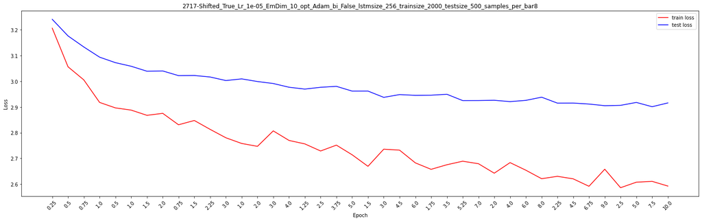

```python
# Primer modelo
name_model = "2717-Shifted_True_Lr_1e-05_EmDim_10_opt_Adam_bi_False_lstmsize_256_trainsize_2000_testsize_500_samples_per_bar8"
train_loss = pickle.load(open("models/chords/" + name_model + "/total_train_loss_array.pickle", "rb"))
test_loss = pickle.load(open("models/chords/" + name_model + "/total_test_loss_array.pickle", "rb"))

plot_loss(train_loss[1], test_loss[1], train_loss[0], name_model)
```

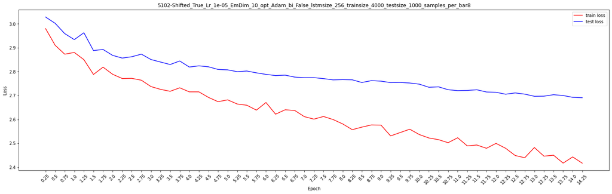

```python
# Segundo modelo
name_model = "5102-Shifted_True_Lr_1e-05_EmDim_10_opt_Adam_bi_False_lstmsize_256_trainsize_4000_testsize_1000_samples_per_bar8"
train_loss = pickle.load(open("models/chords/" + name_model + "/total_train_loss_array.pickle", "rb"))
test_loss = pickle.load(open("models/chords/" + name_model + "/total_test_loss_array.pickle", "rb"))

plot_loss(train_loss[1], test_loss[1], train_loss[0], name_model)
```

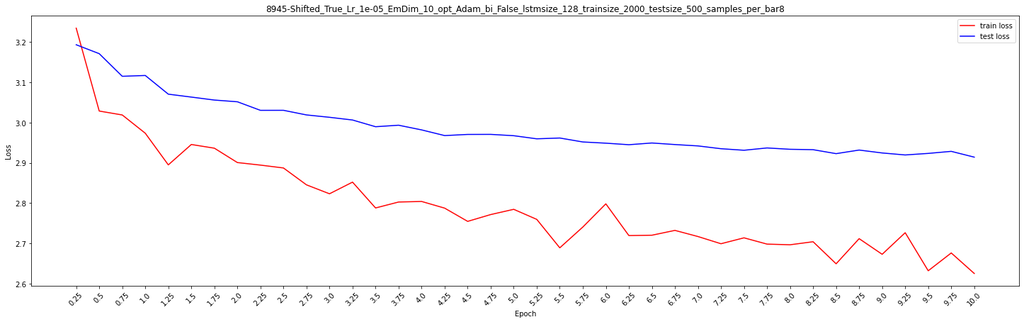

```python
# Tercer modelo
name_model = model_name
train_loss = pickle.load(open("models/chords/" + name_model + "/total_train_loss_array.pickle", "rb"))
test_loss = pickle.load(open("models/chords/" + name_model + "/total_test_loss_array.pickle", "rb"))

plot_loss(train_loss[1], test_loss[1], train_loss[0], name_model)
```

INDICAMOS LOS PARÁMETROS DE CADA MODELO

```python
# Parámetros de cada uno de los modelos
df_model1 = pd.read_csv(
    "models/chords/2717-Shifted_True_Lr_1e-05_EmDim_10_opt_Adam_bi_False_lstmsize_256_trainsize_2000_testsize_500_samples_per_bar8/params_0.txt",
    sep=": ",
    header=None,
    engine="python")
df_model1.columns = ["params", "values"]

df_model2 = pd.read_csv(
    "models/chords/5102-Shifted_True_Lr_1e-05_EmDim_10_opt_Adam_bi_False_lstmsize_256_trainsize_4000_testsize_1000_samples_per_bar8/params_0.txt",
    sep=": ",
    header=None,
    engine="python")
df_model2.columns = ["params", "values"]

df_model3 = pd.read_csv(
    "models/chords/" + name_model + "/params.txt",
    sep=": ",
    header=None,
    engine="python")
df_model3.columns = ["params", "values"]
```

```python
# Comparativa de modelos
df_models = pd.DataFrame(
    data={
        name_model[0:17] + "...": df_model3["values"].values,
        "2717-Shifted_True...": df_model1["values"].values,
        "5102-Shifted_True...": df_model2["values"].values
    },
    index=df_model1["params"].values
)

df_models
```

|  | 8945-Shifted_True... | 2717-Shifted_True... | 5102-Shifted_True... |
| --- | --- | --- | --- |
| epochs | 10 | 10 | 20 |
| train_set_size | 2000 | 2000 | 4000 |
| test_set_size | 500 | 500 | 1000 |
| lstm_size | 128 | 256 | 256 |
| embedding_dim | 10 | 10 | 10 |
| learning_rate | 1e-05 | 1e-05 | 1e-05 |
| shuffle_train_set | True | True | True |
| test_step | 500 | 500 | 1000 |
| bidirectional | False | False | False |
| num_chords | 50 | 50 | 50 |
| chord_n | 3 | 3 | 3 |

EVALUAMOS LAS SOLUCIONES OBTENIDAS

- Primer modelo base (2717-Shifted_True...)

Este modelo es muy similar a nuestro modelo gneerado en el ejercicio (8945-Shifted_True...), tal y como podemos apreciar en la anterior celda de ejecución, solo difieren en un parámetro; lstm_size en este caso es de 256 mientras que en nuestro modelo es de 128.

El rendimiento obtenido es ambos modelos es muy similar, lo cual es algo normal ya que presentan casi los mismos parámetros. Aún así el modelo (2717) se comporta al mejor, debido a que el error de entranamiento se va reduciendo de una forma más suave que en nuestro modelo (8945).

La pérdida obtenida para este modelo en entrenamiento es de 2.6, mientras que en testing la pérdida es de casi 3. Ambas pérdidas son muy similares entre este modelo base y nuestro modelo, en nuestro modelo en el entrenamiento hay un poco más pérdida pero en el testing hay algo menos.

Respondiendo a la pregunta de si hay overfitting, se entiende por overfitting cuando el modelo ajusta muy bien los datos para el entrenamiento, pero no es así para el conjunto de testing. En este caso, vemos que lógicamente la pérdida en el entrenamiento va a ser menor que en el testing, porque el modelo aprende a partir del conjunto de entrenamiento no de test. Otro punto a destacar, es que a medida que avanzan las épocas se van reduciendo ambas pérdidas, de forma progresiva, por lo que en este caso no podemos hablar de un overfitting exagerado, lógicamente algo siempre va a haber, pero en este modelo no es un problema.

- Segundo modelo base (5102-Shifted_True...)

En este caso, los parámetros de este modelo son muy diferentes tanto al modelo anterior (2717) como a nuestro modelo (8945). El número de épocas es 20 y en el resto de modelos 10, el conjunto de entrenamiento es de 4000 y el de test de 1000 mientras que en los otros es de 2000 y 500 respectivamente, el tamaño de la red LSTM es de 256 igual que en el modelo (2717) y el doble que en el modelo (8945), y en este caso se evalúa el modelo cada 1000 canciones y en los otros cada 500.

El rendimiento obtenido en este modelo es mejor que en los otros dos, ya que la pérdida obtenida tanto en train como en test es mucho menor, en este caso estamos hablando de una pérdida de 2.4 para train y de 2.75 para test, en los otros modelos serían de 2.6 para train y casi 3 para test. Por lo tanto, vemos que sí que hay una mejora con este conjunto de parámetros, por lo que podríamos considerar éste como el mejor modelo.

Respecto a si hay overfitting en este modelo, vemos que no es del todo cierto, es verdad que hay algo más de overfitting que en los otros dos modelos ya que consigue ajustar mejor el conjunto de entrenamiento, pero también mejora considerablemente a la hora de evaluar el modelo. Es verdad que la mejora no se realiza de forma proporcional como sucede con los otros dos modelos, es decir, a medida que avanzan las épocas mejora más rápido la pérdida en el entrenamiento que en el test, es por ello que se puede considerar que en este modelo hay overfitting, pero desde mi punto de vista aunque no sea proporcional la mejora la pérdida en test es muy buena, mucho más que en los anteriores modelos.

- Nuestro modelo (8945-Shifted_True)

En este caso, tal y como ya se ha comentado los parámetros son muy similares al modelo (2717), solamente cambia el tamaño de la red LSTM.

El rendimiento obtenido entre este modelo y el modelo (2717) es similar, siendo el modleo (2717) algo mejor.

En este caso, vemos que el modelo va ajustando los datos de entrenamiento a medida que avanzan las épocas, y con ello se va reduciendo la pérdida tanto en train y test, algo que sucedía con el modleo (2717), si en éste no hemos hablando de overfitting en este modelo tampoco ya que las gráficas son muy similares.

# 3 Análisis de la capa de embedding [2 pts]

En esta sección recrearemos la figura 8 del artículo con la red que hemos entrenado y la que mejor performance nos ha dado en la comparación.

```python
from keras.models import load_model
import keras
from keras import backend as K
```

## 3.1 Carga de modelos entrenados y generación de embeddings [1 pts]

3.1.1 Utiliza el *load_model* de **keras** para cargar:

- el modelo que hemos entrenado: *my_model*
- el modelo con mejor performance: *bp_model*

```python
my_model = load_model("/content/drive/MyDrive/PEC3_PAC3/models/chords/8945-Shifted_True_Lr_1e-05_EmDim_10_opt_Adam_bi_False_lstmsize_128_trainsize_2000_testsize_500_samples_per_bar8/model_Epoch10_2000.pickle")
bp_model = load_model("/content/drive/MyDrive/PEC3_PAC3/models/chords/5102-Shifted_True_Lr_1e-05_EmDim_10_opt_Adam_bi_False_lstmsize_256_trainsize_4000_testsize_1000_samples_per_bar8/model_Epoch14_4000.pickle")
```

3.1.2 Ahora crearemos, para cada modelo, un nuevo modelo para los embedding. Para hacer esto, deberás crear un nuevo modelo cuya entrada sea igual a la entrada de los modelos originales y la salida sea el layer "embedding". Esto lo puedes hacer usando la función *get_layer()* del modelo.

```python
# Creamos el modelo para my_model
embed_my_model = keras.models.Model(inputs=my_model.input,outputs=my_model.get_layer(name="embedding").output)

# Creamos el modelo para bp_model
embed_bp_model = keras.models.Model(inputs=bp_model.input,outputs=bp_model.get_layer(name="embedding").output)
```

3.1.3 El modelo de embedding recibe un acorde y devuelve un vector de 10 dimensiones con el embedding para cada acorde. Calcula estos vectores con cada uno de los modelos de embedding

```python
# Calculamos el vector para my_model
acordes = np.array(list(dpf.get_chord_dict()[1].keys()))
output_embed_my_model = embed_my_model.predict(acordes)

# Calculamos el vector para bp_model
output_embed_bp_model = embed_bp_model.predict(acordes)

print("Shape de output_embed_my_model: " + str(output_embed_my_model.shape))
print("Shape de output_embed_bp_model: " + str(output_embed_bp_model.shape))
```

```
Shape de output_embed_my_model: (50, 1, 10)
Shape de output_embed_bp_model: (50, 1, 10)
```

3.1.4 Aplica un squeeze para eliminar los ejes de dimensión 1. El resultado de este squeeze debería ser (50,10)

```python
# Aplicamos squeeze a ambos vectores
output_embed_my_model = np.squeeze(output_embed_my_model, axis=1)
output_embed_bp_model = np.squeeze(output_embed_bp_model, axis=1)

print("Shape de output_embed_my_model: " + str(output_embed_my_model.shape))
print("Shape de output_embed_bp_model: " + str(output_embed_bp_model.shape))
```

```
Shape de output_embed_my_model: (50, 10)
Shape de output_embed_bp_model: (50, 10)
```

## 3.2 Análisis PCA [1 pts]

Para acabar con nuestro análisis de los embeddings, vamos a realizar un proceso de PCA para reducir las dimensiones de los vectores resultantes y poder graficarlos en 2D.

```python
from sklearn.preprocessing import StandardScaler
from sklearn.decomposition import PCA
```

3.2.1 Escalar los vectores y aplicar PCA para reducir a 2 las dimensiones

```python
# Escalamos los vectores
sc_my_model = StandardScaler()
sc_bp_model = StandardScaler()

sc_output_embed_my_model = sc_my_model.fit_transform(output_embed_my_model)
sc_output_embed_bp_model = sc_bp_model.fit_transform(output_embed_bp_model)

# Aplicamos PCA
pca_my_model = PCA(n_components=2)
pca_bp_model = PCA(n_components=2)

pca_output_embed_my_model = pca_my_model.fit_transform(sc_output_embed_my_model)
pca_output_embed_bp_model = pca_bp_model.fit_transform(sc_output_embed_bp_model)
```

3.2.2 Grafica para ambos embeddings los vectores en un scatterplot. Añadele anotaciones con las notas del acorde y comenta el resultado: ¿Observas el efecto word2vect en las gráficas?

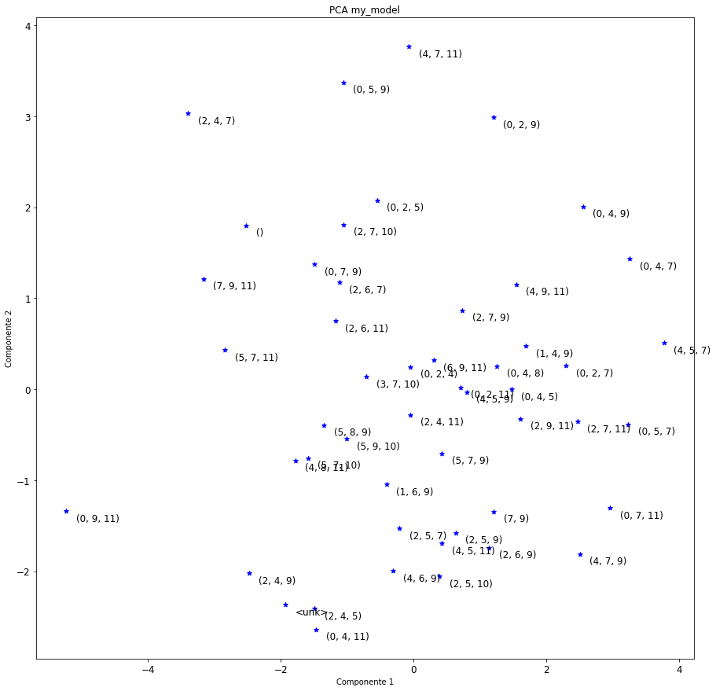

```python
# Gráficamos el scatterplot para my_model
fig, ax = plt.subplots(figsize=(15,15))
plt.tick_params(labelsize=12)
style = dict(size=12, color='black')

for i in range(0, len(idx_2_chord)):
  try:
    # ax.text(-pca_output_embed_my_model[i,0]-0.15,pca_output_embed_my_model[i,1]+0.11, ddd[idx_2_chord[i]],**style)
    ax.text(-pca_output_embed_my_model[i,0]+0.15,pca_output_embed_my_model[i,1]-0.11, idx_2_chord[i],**style)
    ax.scatter(-pca_output_embed_my_model[i,0],pca_output_embed_my_model[i,1], c="blue", marker="*")

  except:
    pass

plt.title("PCA my_model")
plt.xlabel("Componente 1")
plt.ylabel("Componente 2")
plt.show()
```

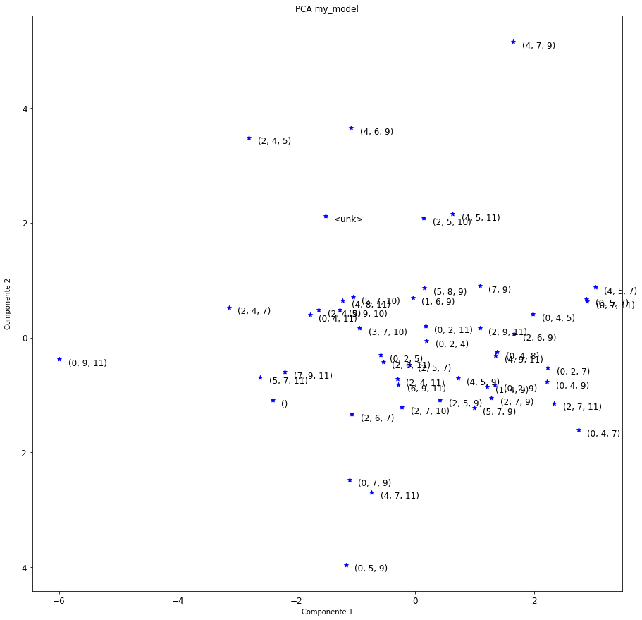

```python
# Gráficamos el scatterplot para my_model
fig, ax = plt.subplots(figsize=(15,15))
plt.tick_params(labelsize=12)
style = dict(size=12, color='black')

for i in range(0, len(idx_2_chord)):
  try:
    # ax.text(-pca_output_embed_bp_model[i,0]-0.15,pca_output_embed_bp_model[i,1]+0.11, ddd[idx_2_chord[i]],**style)
    ax.text(-pca_output_embed_bp_model[i,0]+0.15,pca_output_embed_bp_model[i,1]-0.11, idx_2_chord[i],**style)
    ax.scatter(-pca_output_embed_bp_model[i,0],pca_output_embed_bp_model[i,1], c="blue", marker="*")

  except:
    pass

plt.title("PCA my_model")
plt.xlabel("Componente 1")
plt.ylabel("Componente 2")
plt.show()
```

- Conclusiones de los gráficos

Sí que podemos apreciar el efecto word2vect, ya que aquellos acordes que comparten notas están más juntos, mientras que acordes con notas muy dispares están más alejados.

Usa esta función para obtener un índice para los acordes y sus notas

```python
def get_chord_dict():
    chord_to_index = pickle.load(open(dict_path + chord_dict_name, 'rb'))
    index_to_chord = pickle.load(open(dict_path + index_dict_name, 'rb'))
    return chord_to_index, index_to_chord

chord_to_index, idx_2_chord = get_chord_dict()
```

3.2.3 Crea una función para calcular todas las distancias entre los primero 20 acordes. Luego haz una lista con las 10 distancias mínimas para ambos modelos. ¿Están relacionados estos acordes con distancias mínimas?

```python
from scipy.spatial import distance

# Método que calcula todas las distancias
def calculate_distances(pca, max=20):
  indices = [i for i in range(max)]
  pca_max = pca[:max]
  datos = np.zeros(shape=(max,max))

  # Calculamos las distancias para cada punto
  for i in range(max):
    for j in range(max):
      if i != j:
        datos[i][j] = distance.euclidean(pca_max[i], pca_max[j])

  return datos

# Método que devuelve las 10 distancias mínimas
def top_10_distances(distances):
  datos = {}
  par_acordes_visitados = []

  for top in range(10):
    min_value = 100
    min_position = (-1,-1) # Indica también los acordes, el primer elemento de la tupla un acorde y el otro elemento el otro

    for i in range(distances.shape[0]):
      for j in range(distances[i].shape[0]):
        if i != j:
          if ((i, j) not in par_acordes_visitados):
            if distances[i][j] < min_value:
              min_value = distances[i][j]
              min_position = (i,j)

    datos[min_position] = min_value
    par_acordes_visitados.append(min_position)
    par_acordes_visitados.append((min_position[1], min_position[0])) # Guardamos el inverso, ya que la distancia es la misma de A a B que de B a A

  return datos
```

```python
# Distancias para my_model
distances_my_model = calculate_distances(pca_output_embed_my_model)
top_10_distances_my_model = top_10_distances(distances_my_model)

for key, value in top_10_distances_my_model.items():
  print("Distancia entre los acordes -" + str(key[0]) + "- " + str(idx_2_chord[key[0]]) + " y -" + str(key[1]) + "- " + str(idx_2_chord[key[1]]) + " es: " + str(round(value, 2)))
```

```
Distancia entre los acordes -17- (0, 4, 5) y -19- (1, 4, 9) es: 0.52
Distancia entre los acordes -8- (0, 2, 7) y -19- (1, 4, 9) es: 0.64
Distancia entre los acordes -3- (2, 7, 11) y -8- (0, 2, 7) es: 0.64
Distancia entre los acordes -12- (0, 7, 11) y -14- (4, 7, 9) es: 0.68
Distancia entre los acordes -3- (2, 7, 11) y -7- (0, 5, 7) es: 0.76
Distancia entre los acordes -5- (2, 5, 9) y -15- (2, 5, 7) es: 0.85
Distancia entre los acordes -8- (0, 2, 7) y -17- (0, 4, 5) es: 0.86
Distancia entre los acordes -5- (2, 5, 9) y -11- (5, 7, 9) es: 0.9
Distancia entre los acordes -1- (0, 4, 7) y -2- (0, 4, 9) es: 0.91
Distancia entre los acordes -7- (0, 5, 7) y -12- (0, 7, 11) es: 0.96
```

```python
# Distancias para bp_model
distances_bp_model = calculate_distances(pca_output_embed_bp_model)
top_10_distances_bp_model = top_10_distances(distances_bp_model)

for key, value in top_10_distances_bp_model.items():
  print("Distancia entre los acordes -" + str(key[0]) + "- " + str(idx_2_chord[key[0]]) + " y -" + str(key[1]) + "- " + str(idx_2_chord[key[1]]) + " es: " + str(round(value, 2)))
```

```
Distancia entre los acordes -7- (0, 5, 7) y -12- (0, 7, 11) es: 0.04
Distancia entre los acordes -13- (0, 2, 9) y -19- (1, 4, 9) es: 0.14
Distancia entre los acordes -9- (2, 7, 9) y -19- (1, 4, 9) es: 0.22
Distancia entre los acordes -9- (2, 7, 9) y -13- (0, 2, 9) es: 0.25
Distancia entre los acordes -2- (0, 4, 9) y -8- (0, 2, 7) es: 0.25
Distancia entre los acordes -9- (2, 7, 9) y -11- (5, 7, 9) es: 0.34
Distancia entre los acordes -2- (0, 4, 9) y -3- (2, 7, 11) es: 0.39
Distancia entre los acordes -11- (5, 7, 9) y -19- (1, 4, 9) es: 0.43
Distancia entre los acordes -6- (4, 7, 11) y -10- (0, 7, 9) es: 0.43
Distancia entre los acordes -16- () y -18- (5, 7, 11) es: 0.45
```

# 4. Rueda de 5tas (Bonus Track) [0.5 pts]

En este bonus track, y usando lo mismo que has usado para los apartados anteriores, podrás dibujar la rueda de quintas con datos entrenados sobre la misma base de datos, pero no hacer el shifteo de los acordes.

Usa los datos que encontrarás en la carpeta *models/chords/9671-Shifted_False...* para repetir el proceso del análisis de PCA

Una vez tienes los vectores, llama a las siguientes funciones para dibujar la rueda de quintas

```python
# Cargamos el modelo
quintas_model = load_model("/content/drive/MyDrive/PEC3_PAC3/models/chords/9671-Shifted_False_Lr_1.5e-05_EmDim_10_opt_Adam_bi_False_lstmsize_256_trainsize_4000_testsize_1000_samples_per_bar8/model_Epoch8_4000.pickle")

# Creamos el modelo embedding para las quintas
embed_quintas_model = keras.models.Model(inputs=quintas_model.input,outputs=quintas_model.get_layer(name="embedding").output)

# Calculamos el vector
acordes = np.array(list(dpf.get_chord_dict()[1].keys()))
output_embed_quintas_model = embed_quintas_model.predict(acordes)

# Aplicamos un squeeze para eliminar los ejes de dimensión 1
output_embed_quintas_model = np.squeeze(output_embed_quintas_model, axis=1)

# Escalamos el vector
sc_quintas_model = StandardScaler()
sc_output_embed_quintas_model = sc_quintas_model.fit_transform(output_embed_quintas_model)

# Aplicamos PCA
pca_quintas_model = PCA(n_components=2)
pca_output_embed_quintas_model = pca_quintas_model.fit_transform(sc_output_embed_quintas_model)
```

```python
def get_chord_dict_no_shifted():
    chord_to_index = pickle.load(open('data/chord_dict.pickle', 'rb'))
    index_to_chord = pickle.load(open('data/index_dict.pickle', 'rb'))
    return chord_to_index, index_to_chord

chord_to_index_, idx_2_chord_ = get_chord_dict_no_shifted()
```

```python
ddd={tuple((0,4,7)):'C',
tuple((1,5,8)):'C#',
tuple((2,6,9)):'D',
tuple((3,7,10)):'D#',
tuple((4,8,11)):'E',
tuple((0,5,9)):'F',
tuple((1,6,10)):'F#',
tuple((2,7,11)):'G',
tuple((0,3,8)):'G#',
tuple((1,4,9)):'A',
tuple((2,5,10)):'A#',
tuple((3,6,11)):'B'}


def plot_5th_circle(X_chords_2d):

  fig, ax = plt.subplots()
  fig.set_size_inches(8, 6)

  plt.tick_params(labelsize=12)

  style = dict(size=12, color='black')

  for i in range(0,len(idx_2_chord_)):
    try:
      ax.text(-X_chords_2d[i,0]-0.32,X_chords_2d[i,1]+0.11, ddd[idx_2_chord_[i]],**style)
      ax.scatter(-X_chords_2d[i,0],X_chords_2d[i,1], c="blue", marker="*")

    except:
      pass

  plt.show()
```

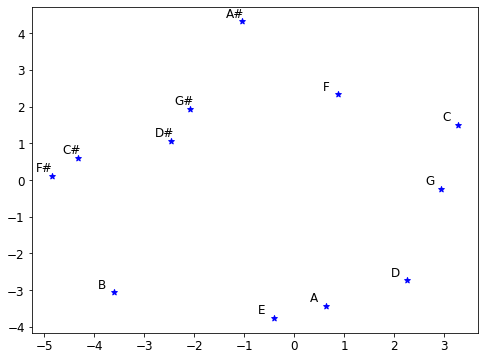

```python
plot_5th_circle(pca_output_embed_quintas_model) #pasa los vectores luego del análisis de PCA
```